# Activity 4: Data wrangling

## Baseball data

The `Teams` data in the `Lahman` package contains information on professional baseball teams since 1871.

#### Question 1

Using the `Teams` data, create a plot of the number of home runs scored (`HR`) and allowed (`HRA`) by the Chicago Cubs (`teamID` CHN) in each season. Your plot should look like close to this:

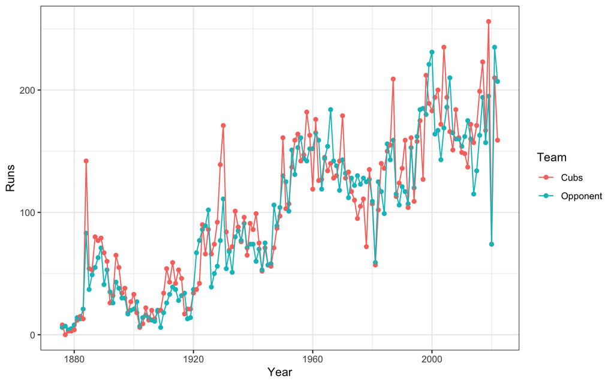

You may use whichever R functions you like to create the plot, but the axes and legend should be labeled as in the plot above.

## Practice pivoting

#### Question 2

The code below creates a data frame called `df1`:

```r
df1 <- data.frame(
  grp = c("A", "A", "B", "B"),
  sex = c("F", "M", "F", "M"),
  meanL = c(0.225, 0.47, 0.325, 0.547),
  sdL = c(0.106, 0.325, 0.106, 0.308),
  meanR = c(0.34, 0.57, 0.4, 0.647),
  sdR = c(0.0849, 0.325, 0.0707, 0.274)
)

df1
```

```
##   grp sex meanL   sdL meanR    sdR
## 1   A   F 0.225 0.106 0.340 0.0849
## 2   A   M 0.470 0.325 0.570 0.3250
## 3   B   F 0.325 0.106 0.400 0.0707
## 4   B   M 0.547 0.308 0.647 0.2740
```

Using `pivot_longer` and `pivot_wider`, reshape `df1` to produce the following output:

```
## # A tibble: 2 × 9
##   grp   F.meanL F.sdL F.meanR  F.sdR M.meanL M.sdL M.meanR M.sdR
##   <chr>   <dbl> <dbl>   <dbl>  <dbl>   <dbl> <dbl>   <dbl> <dbl>
## 1 A       0.225 0.106    0.34 0.0849   0.47  0.325   0.57  0.325
## 2 B       0.325 0.106    0.4  0.0707   0.547 0.308   0.647 0.274
```

Remember that the `?` provides documentation in R. For example, running `?pivot_wider` in the console gives helpful information about the `pivot_wider` function.

## Practice pivoting

The code below creates a data frame called `df2`:

```r
df2 <- data.frame(id = rep(c(1, 2, 3), 2),
                  group = rep(c("T", "C"), each=3),
                  vals = c(4, 6, 8, 5, 6, 10))

df2
```

```
##   id group vals
## 1  1     T    4
## 2  2     T    6
## 3  3     T    8
## 4  1     C    5
## 5  2     C    6
## 6  3     C   10
```

An analyst wants to calculate the pairwise differences between the Treatment (T) and Control (C) values for each individual in this dataset. They use the following code:

```r
Treat <- filter(df2, group == "T")
Control <- filter(df2, group == "C")
all <- mutate(Treat, diff = Treat$vals - Control$vals)
all
```

```
##   id group vals diff
## 1  1     T    4   -1
## 2  2     T    6    0
## 3  3     T    8   -2
```

#### Question 3

Verify that this code works for this example and generates the correct values of -1, 0, and -2. Describe two problems that might arise if the data set is not sorted in a particular order or if one of the observations is missing for one of the subjects.

#### Question 4

Provide an alternative approach to generate the `diff` variable, using `group_by` and `summarize` to produce the following output:

```
## # A tibble: 3 × 2
##      id  diff
##   <dbl> <dbl>
## 1     1    -1
## 2     2     0
## 3     3    -2
```

#### Question 5

Provide an alternative approach to generate the `diff` variable that uses `pivot_wider` and `mutate` to produce the following output:

```
## # A tibble: 3 × 4
##      id     T     C  diff
##   <dbl> <dbl> <dbl> <dbl>
## 1     1     4     5    -1
## 2     2     6     6     0
## 3     3     8    10    -2
```

## Analyzing simulation results

Your friend ran simulations to compare three different methods for calculating 95% confidence intervals for $\beta_1$ in a linear regression model. Their data is store in the file `sim_results.csv`, which can be imported into R as follows:

```r
sim_results <- read.csv("https://sta279-f23.github.io/homework/sim_results.csv")
```

#### Question 6

Plot the observed coverage for each method (the fraction of times the confidence interval contained $\beta_1$) as a function of sample size. Your final plot should look as close as possible to this:

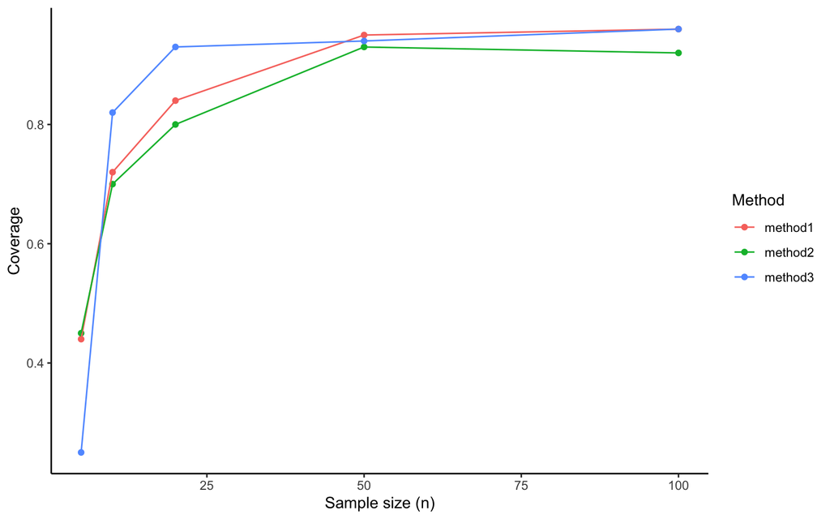

You will likely need to use some combination of the following functions: `pivot_longer`, `mutate`, `select`, `across`, `c_across`, `rowwise`